# Report for Rhode_Island_Feehan_Grace_Narvaez

## 1. The Data

Here is your dataset as we reprocessed it. Please take a look.

**Click to see the clean data**

```r
#
 study_data |>
          kable( format = "html") %>%
          kable_styling(position = "center", full_width = F, bootstrap_options = c("striped","hover"))%>%
          scroll_box( width = "1000px", height = "500px", fixed_thead = T)
```

| Entry | Study | Region | Site | Depth.m | Sample.Year | Sample.Month | Sample.Day | Latitude | Longitude | Taxon | Fixed.or.Random | Sample.Unit.Size.sq.m | Percent.Cover | Stipe.Density.num.per.sq.m | Individual.Density.num.per.sq.m | Biomass.kg.wet.per.sq.m |
| --- | --- | --- | --- | --- | --- | --- | --- | --- | --- | --- | --- | --- | --- | --- | --- | --- |
| 1 | Rhode_Island_Feehan_Grace_Narvaez | NA | Fort Wetherill | 2 | 1980 | 5 | NA | 41.476 | -71.357 | Saccharina latissima, Laminaria digitata | random | 0.100 | NA | 60.410000 | 60.410000 | NA |
| 2 | Rhode_Island_Feehan_Grace_Narvaez | NA | Fort Wetherill | 2 | 1980 | 6 | NA | 41.476 | -71.357 | Saccharina latissima, Laminaria digitata | random | 0.100 | NA | 93.970000 | 93.970000 | NA |
| 3 | Rhode_Island_Feehan_Grace_Narvaez | NA | Fort Wetherill | 2 | 1980 | 7 | NA | 41.476 | -71.357 | Saccharina latissima, Laminaria digitata | random | 0.100 | NA | 46.623123 | 46.623123 | NA |
| 4 | Rhode_Island_Feehan_Grace_Narvaez | NA | Fort Wetherill | 2 | 1980 | 8 | NA | 41.476 | -71.357 | Saccharina latissima, Laminaria digitata | random | 0.100 | NA | 109.390000 | 109.390000 | NA |
| 5 | Rhode_Island_Feehan_Grace_Narvaez | NA | Fort Wetherill | 2 | 1980 | 9 | NA | 41.476 | -71.357 | Saccharina latissima, Laminaria digitata | random | 0.100 | NA | 75.530000 | 75.530000 | NA |
| 6 | Rhode_Island_Feehan_Grace_Narvaez | NA | Fort Wetherill | 2 | 1981 | 2 | NA | 41.476 | -71.357 | Saccharina latissima, Laminaria digitata | random | 0.100 | NA | 45.540000 | 45.540000 | NA |
| 7 | Rhode_Island_Feehan_Grace_Narvaez | NA | Fort Wetherill | 2 | 1981 | 4 | NA | 41.476 | -71.357 | Saccharina latissima, Laminaria digitata | random | 0.100 | NA | 87.931480 | 87.931480 | NA |
| 8 | Rhode_Island_Feehan_Grace_Narvaez | NA | Fort Wetherill | 2 | 1981 | 6 | NA | 41.476 | -71.357 | Saccharina latissima, Laminaria digitata | random | 0.100 | NA | 247.170000 | 247.170000 | NA |
| 9 | Rhode_Island_Feehan_Grace_Narvaez | NA | Fort Wetherill | 2 | 1980 | NA | NA | 41.476 | -71.357 | Saccharina latissima, Laminaria digitata | random | 0.100 | NA | NA | NA | 3.46903 |
| 10 | Rhode_Island_Feehan_Grace_Narvaez | NA | Fort Wetherill | 2 | 1981 | NA | NA | 41.476 | -71.357 | Saccharina latissima, Laminaria digitata | random | 0.100 | NA | NA | NA | 4.85841 |
| 11 | Rhode_Island_Feehan_Grace_Narvaez | NA | Land's End | 2 | 1980 | NA | NA | 41.451 | -71.313 | Saccharina latissima, Laminaria digitata | random | 0.100 | NA | 87.180000 | 87.180000 | 12.73783 |
| 12 | Rhode_Island_Feehan_Grace_Narvaez | NA | Land's End | 2 | 1981 | NA | NA | 41.451 | -71.313 | Saccharina latissima, Laminaria digitata | random | 0.100 | NA | 252.200000 | 252.200000 | 17.93976 |
| 13 | Rhode_Island_Feehan_Grace_Narvaez | NA | Bass Rock Rd | 2 | 2018 | 6 | 27 | 41.405 | -71.455 | Saccharina latissima, Laminaria digitata | random | 0.625 | NA | 9.250000 | 9.250000 | 107.84000 |
| 14 | Rhode_Island_Feehan_Grace_Narvaez | NA | Bass Rock Rd | 6 | 2018 | 6 | 27 | 41.405 | -71.455 | Saccharina latissima, Laminaria digitata | random | 0.625 | NA | 0.000000 | 0.000000 | NA |
| 15 | Rhode_Island_Feehan_Grace_Narvaez | NA | Fort Wetherill | 2 | 2018 | 6 | 20 | 41.476 | -71.357 | Saccharina latissima, Laminaria digitata | random | 0.625 | NA | 176.625000 | 176.625000 | 132.82000 |
| 16 | Rhode_Island_Feehan_Grace_Narvaez | NA | Fort Wetherill | 6 | 2018 | 6 | 20 | 41.476 | -71.357 | Saccharina latissima, Laminaria digitata | random | 0.625 | NA | 17.100000 | 17.100000 | NA |
| 17 | Rhode_Island_Feehan_Grace_Narvaez | NA | Fort Wetherill | NA | 2018 | 8 | 30 | 41.476 | -71.357 | Saccharina latissima, Laminaria digitata | random | 0.625 | NA | 9.333333 | 9.333333 | NA |
| 18 | Rhode_Island_Feehan_Grace_Narvaez | NA | Fort Wetherill | 2 | 2018 | 11 | 30 | 41.476 | -71.357 | Saccharina latissima, Laminaria digitata | random | 0.625 | NA | 5.800000 | 5.800000 | NA |
| 19 | Rhode_Island_Feehan_Grace_Narvaez | NA | Fort Wetherill | 6 | 2018 | 11 | 30 | 41.476 | -71.357 | Saccharina latissima, Laminaria digitata | random | 0.625 | NA | 0.600000 | 0.600000 | NA |
| 20 | Rhode_Island_Feehan_Grace_Narvaez | NA | Land's End | 2 | 2018 | 7 | 12 | 41.451 | -71.313 | Saccharina latissima, Laminaria digitata | random | 0.625 | NA | 0.000000 | 0.000000 | 0.00000 |
| 21 | Rhode_Island_Feehan_Grace_Narvaez | NA | Land's End | 6 | 2018 | 7 | 12 | 41.451 | -71.313 | Saccharina latissima, Laminaria digitata | random | 0.625 | NA | 1.200000 | 1.200000 | NA |

Here is your dataset as where we have now summed across all kelp species and put into the KelpTime main database format.

**Click to see the data in kelptime format**

```r
#|
kelptime_study |>
         kable( format = "html") %>%
         kable_styling(position = "center", full_width = F, bootstrap_options = c("striped","hover"))%>%
         scroll_box( width = "1000px", height = "500px", fixed_thead = T)
```

| study | site | period | latitude | longitude | sample_unit_size_sq_m | sasdate | max_depth | mean_depth | min_depth | biomass_kg_wet_per_sq_m | stipe_density_num_per_sq_m | individual_density_num_per_sq_m | percent_cover | has_bm | has_sd | has_id | has_pc | use_which | focalKelp | focalUnit | geometry | ecoregion | province | realm | focal_std_by_ecoregion | focal_std_by_province | focal_std_by_realm | ln_focal_std_by_ecoregion | ln_focal_std_by_province | … |
| --- | --- | --- | --- | --- | --- | --- | --- | --- | --- | --- | --- | --- | --- | --- | --- | --- | --- | --- | --- | --- | --- | --- | --- | --- | --- | --- | --- | --- | --- | --- |
| Rhode_Island_Feehan_Grace_Narvaez | Fort Wetherill | 1 | 41.476 | -71.357 | 0.100 | 1980-05-15 | 2 | 2 | 2 | NA | 60.410000 | 60.410000 | NA | 7 | 15 | 15 | 0 | 2 | 60.410000 | Stipe density | c(-71.357, 41.476) | Virginian | Cold Temperate Northwest Atlantic | Temperate Northern Atlantic | 0.2423981 | 0.2423981 | 0.2423981 | -1.3767476 | -1.3767476 | … |
| Rhode_Island_Feehan_Grace_Narvaez | Fort Wetherill | 2 | 41.476 | -71.357 | 0.100 | 1980-06-15 | 2 | 2 | 2 | 3.46903 | 93.970000 | 93.970000 | NA | 7 | 15 | 15 | 0 | 2 | 93.970000 | Stipe density | c(-71.357, 41.476) | Virginian | Cold Temperate Northwest Atlantic | Temperate Northern Atlantic | 0.3770593 | 0.3770593 | 0.3770593 | -0.9491774 | -0.9491774 | … |
| Rhode_Island_Feehan_Grace_Narvaez | Fort Wetherill | 3 | 41.476 | -71.357 | 0.100 | 1980-07-15 | 2 | 2 | 2 | NA | 46.623123 | 46.623123 | NA | 7 | 15 | 15 | 0 | 2 | 46.623123 | Stipe density | c(-71.357, 41.476) | Virginian | Cold Temperate Northwest Atlantic | Temperate Northern Atlantic | 0.1870776 | 0.1870776 | 0.1870776 | -1.6241578 | -1.6241578 | … |
| Rhode_Island_Feehan_Grace_Narvaez | Fort Wetherill | 4 | 41.476 | -71.357 | 0.100 | 1980-08-15 | 2 | 2 | 2 | NA | 109.390000 | 109.390000 | NA | 7 | 15 | 15 | 0 | 2 | 109.390000 | Stipe density | c(-71.357, 41.476) | Virginian | Cold Temperate Northwest Atlantic | Temperate Northern Atlantic | 0.4389328 | 0.4389328 | 0.4389328 | -0.8008821 | -0.8008821 | … |
| Rhode_Island_Feehan_Grace_Narvaez | Fort Wetherill | 5 | 41.476 | -71.357 | 0.100 | 1980-09-15 | 2 | 2 | 2 | NA | 75.530000 | 75.530000 | NA | 7 | 15 | 15 | 0 | 2 | 75.530000 | Stipe density | c(-71.357, 41.476) | Virginian | Cold Temperate Northwest Atlantic | Temperate Northern Atlantic | 0.3030679 | 0.3030679 | 0.3030679 | -1.1613353 | -1.1613353 | … |
| Rhode_Island_Feehan_Grace_Narvaez | Fort Wetherill | 6 | 41.476 | -71.357 | 0.100 | 1981-02-15 | 2 | 2 | 2 | NA | 45.540000 | 45.540000 | NA | 7 | 15 | 15 | 0 | 2 | 45.540000 | Stipe density | c(-71.357, 41.476) | Virginian | Cold Temperate Northwest Atlantic | Temperate Northern Atlantic | 0.1827315 | 0.1827315 | 0.1827315 | -1.6464572 | -1.6464572 | … |
| Rhode_Island_Feehan_Grace_Narvaez | Fort Wetherill | 7 | 41.476 | -71.357 | 0.100 | 1981-04-15 | 2 | 2 | 2 | NA | 87.931480 | 87.931480 | NA | 7 | 15 | 15 | 0 | 2 | 87.931480 | Stipe density | c(-71.357, 41.476) | Virginian | Cold Temperate Northwest Atlantic | Temperate Northern Atlantic | 0.3528294 | 0.3528294 | 0.3528294 | -1.0138225 | -1.0138225 | … |
| Rhode_Island_Feehan_Grace_Narvaez | Fort Wetherill | 8 | 41.476 | -71.357 | 0.100 | 1981-06-15 | 2 | 2 | 2 | 4.85841 | 247.170000 | 247.170000 | NA | 7 | 15 | 15 | 0 | 2 | 247.170000 | Stipe density | c(-71.357, 41.476) | Virginian | Cold Temperate Northwest Atlantic | Temperate Northern Atlantic | 0.9917819 | 0.9917819 | 0.9917819 | 0.0017803 | 0.0017803 | … |
| Rhode_Island_Feehan_Grace_Narvaez | Fort Wetherill | 9 | 41.476 | -71.357 | 0.625 | 2018-06-20 | 6 | 4 | 2 | 132.82000 | 96.862500 | 96.862500 | NA | 7 | 15 | 15 | 0 | 2 | 96.862500 | Stipe density | c(-71.357, 41.476) | Virginian | Cold Temperate Northwest Atlantic | Temperate Northern Atlantic | 0.3886656 | 0.3886656 | 0.3886656 | -0.9196324 | -0.9196324 | … |
| Rhode_Island_Feehan_Grace_Narvaez | Fort Wetherill | 10 | 41.476 | -71.357 | 0.625 | 2018-08-30 | 9999 | 9999 | 9999 | NA | 9.333333 | 9.333333 | NA | 7 | 15 | 15 | 0 | 2 | 9.333333 | Stipe density | c(-71.357, 41.476) | Virginian | Cold Temperate Northwest Atlantic | Temperate Northern Atlantic | 0.0374505 | 0.0374505 | 0.0374505 | -3.0480690 | -3.0480690 | … |
| Rhode_Island_Feehan_Grace_Narvaez | Fort Wetherill | 11 | 41.476 | -71.357 | 0.625 | 2018-11-30 | 6 | 4 | 2 | NA | 3.200000 | 3.200000 | NA | 7 | 15 | 15 | 0 | 2 | 3.200000 | Stipe density | c(-71.357, 41.476) | Virginian | Cold Temperate Northwest Atlantic | Temperate Northern Atlantic | 0.0128402 | 0.0128402 | 0.0128402 | -3.7792349 | -3.7792349 | … |
| Rhode_Island_Feehan_Grace_Narvaez | Land's End | 1 | 41.451 | -71.313 | 0.100 | 1980-06-15 | 2 | 2 | 2 | 12.73783 | 87.180000 | 87.180000 | NA | 7 | 15 | 15 | 0 | 2 | 87.180000 | Stipe density | c(-71.313, 41.451) | Virginian | Cold Temperate Northwest Atlantic | Temperate Northern Atlantic | 0.3498141 | 0.3498141 | 0.3498141 | -1.0221678 | -1.0221678 | … |
| Rhode_Island_Feehan_Grace_Narvaez | Land's End | 2 | 41.451 | -71.313 | 0.100 | 1981-06-15 | 2 | 2 | 2 | 17.93976 | 252.200000 | 252.200000 | NA | 7 | 15 | 15 | 0 | 2 | 252.200000 | Stipe density | c(-71.313, 41.451) | Virginian | Cold Temperate Northwest Atlantic | Temperate Northern Atlantic | 1.0119650 | 1.0119650 | 1.0119650 | 0.0217272 | 0.0217272 | … |
| Rhode_Island_Feehan_Grace_Narvaez | Land's End | 3 | 41.451 | -71.313 | 0.625 | 2018-07-12 | 6 | 4 | 2 | 0.00000 | 0.600000 | 0.600000 | NA | 7 | 15 | 15 | 0 | 2 | 0.600000 | Stipe density | c(-71.313, 41.451) | Virginian | Cold Temperate Northwest Atlantic | Temperate Northern Atlantic | 0.0024075 | 0.0024075 | 0.0024075 | -4.3894518 | -4.3894518 | … |

## 2. Plots of raw data

### 2.1 By metric

Here is what your data looks like with all sites plotted together looking at each sampling metric.

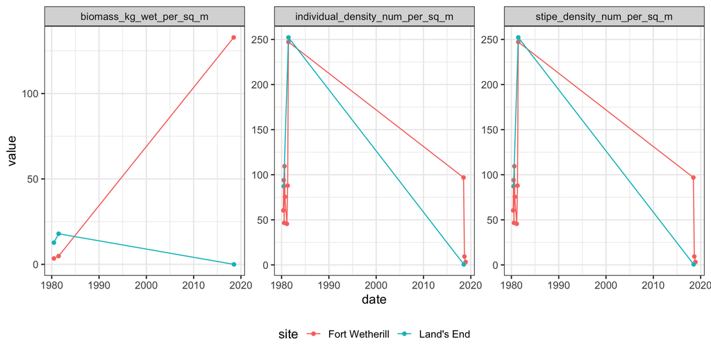

```r
kelptime_study_measurement_long <-
  kelptime_study |>
  tidyr::pivot_longer(cols =biomass_kg_wet_per_sq_m:percent_cover) |>
  filter(!is.na(value))

ggplot(kelptime_study_measurement_long,
       aes(x = date, y = value,
           color = site)) +
  geom_point() +
  geom_line() +
  facet_wrap(vars(name), scale = "free_y")
```

### 2.2 Standardized data

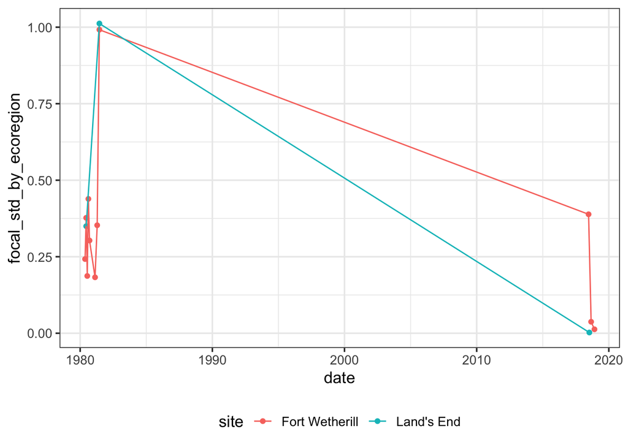

```r
ggplot(kelptime_study,
       aes(x = date, y = focal_std_by_ecoregion,
           color = site)) +
  geom_point() +
  geom_line()
```

### 2.3 Standardized data by site

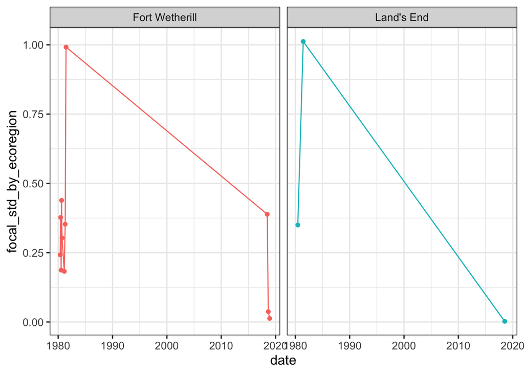

```r
ggplot(kelptime_study,
       aes(x = date, y = focal_std_by_ecoregion,
           color = site)) +
  geom_point() +
  geom_line() +
  facet_wrap(vars(site)) +
  guides(color = "none")
```

## 3. Modeled timeseries resuls

We fit two models. One where the slope varies by ecoregion (note: the GOSL and Newfoundland are collapsed) and one where the slope does not vary by ecoregion. Based on the modeled results, here is the smoothed fits to your data. Note - thus far, the model with a common slope appears to be the correct is the one with a common slope (best fit in terms of prediction and p-value for slope*ecoregion is not distinguishable from 0).

**Note** - the study (black) line might not line up in the middle or on trajectories, as it is shrunken in towards the grand mean for the ecoregion.

### 3.1 Slope Varying by Ecoregion Model

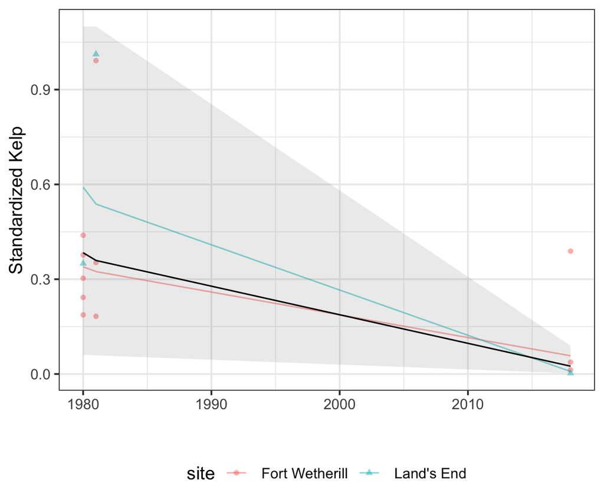

```r
mod_ecoregion <- readRDS("models/mod_ecoregion.rds")


# for plotting to do the back transform
exp_trans <- function(dat){

  dat |>
    mutate(
      Predicted = exp(Predicted)-0.01,
           CI_low = exp(CI_low)-0.01,
           CI_high = exp(CI_high)-0.01,
           CI_high = ifelse(CI_high>1.1, 1.1, CI_high)
    )|>
               mutate(trajectory =
                        gsub(study[1], "", trajectory))

}


re_ecoregion <- ranef(mod_ecoregion)$cond$study |>
  as_tibble(rownames = "study")  |>
  filter(study == params$study) |>
  pull(`(Intercept)`)


dat_fixed_ecoregion <- estimate_relation(mod_ecoregion,
                               include_random = FALSE,
                  length = 200,
                  data = kelptime_study) |>
  mutate(Predicted = Predicted + re_ecoregion,
         CI_high = CI_high + re_ecoregion,
         CI_low = CI_low + re_ecoregion) |>
  exp_trans()

dat_traj_ecoregion <- estimate_relation(mod_ecoregion,
                              include_random = TRUE,
                  length = 200,
                  data = kelptime_study) |>
    exp_trans()


ggplot(dat_traj_ecoregion, aes(x = year)) +
  geom_line(aes(y = Predicted,
                color = trajectory), alpha = 0.5) +
  geom_point(aes(y = focal_std_by_ecoregion,
                 group = trajectory,
                 shape = trajectory,
                 color = trajectory), alpha = 0.5,
             data = kelptime_study |>
               mutate(trajectory =
                        gsub(study[1], "", trajectory))) +
  geom_line(data = dat_fixed_ecoregion,
            aes(y = Predicted), color = "black") +
  geom_ribbon(data = dat_fixed_ecoregion,
            aes(y = Predicted,
                ymin = CI_low,
                ymax = CI_high), color = NA,
            alpha = 0.1) +
  labs(x = "", y = "Standardized Kelp",
      color = "site", shape = "site")
```

### 3.2 Common Slope Model

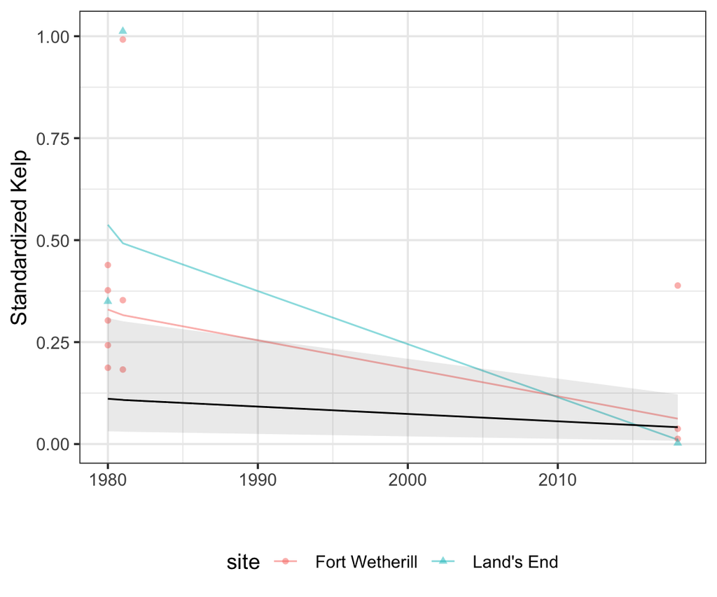

```r
mod_common_slope <- readRDS("models/mod_common_slope.rds")

re <- ranef(mod_common_slope)$cond$study |>
  as_tibble(rownames = "study")  |>
  filter(study == params$study) |>
  pull(`(Intercept)`)


dat_fixed <- estimate_relation(mod_common_slope,
                               include_random = FALSE,
                  length = 200,
                  data = kelptime_study) |>
  mutate(Predicted = Predicted + re,
         CI_high = CI_high + re_ecoregion,
         CI_low = CI_low + re_ecoregion) |>
  exp_trans()

dat_traj <- estimate_relation(mod_common_slope,
                              include_random = TRUE,
                  length = 200,
                  data = kelptime_study) |>
    exp_trans()

ggplot(dat_traj, aes(x = year)) +
  geom_line(aes(y = Predicted,
                color = trajectory), alpha = 0.5) +
  geom_point(aes(y = focal_std_by_ecoregion,
                 group = trajectory,
                 shape = trajectory,
                 color = trajectory), alpha = 0.5,
             data = kelptime_study |>
               mutate(trajectory =
                        gsub(study[1], "", trajectory))) +
  geom_line(data = dat_fixed,
            aes(y = Predicted), color = "black") +
  geom_ribbon(data = dat_fixed,
            aes(y = Predicted,
                ymin = CI_low,
                ymax = CI_high), color = NA,
            alpha = 0.1) +
  labs(x = "", y = "Standardized Kelp",
      color = "site", shape = "site")
```